# Principal Component Analysis: Indian Stock Market

by JUMEX365

## Dataset Description

```r
stock <- read.csv("BRITANNIA.csv")[,1:12]
stock$Date <- ymd(stock$Date)
```

The dataset contains the price history and trading volumes of the BRITTANIA stocks from the index NIFTY 50 from NSE (National Stock Exchange) India. This dataset is a part of NIFTY-50 Stock Market Data (2000 - 2021) database.

“NIFTY-50 Stock Market Data: BRITANNIA” dataset contains 5305 stock market observations of Britannia Industries Ltd from 3 Jan 2000 to 30 Apr 2021.

Variables in dataset:

1. *Date* - Date [datetime]
2. *Symbol* - Symbol [character]
3. *Series* - Type of security [factor]
4. *Close* - Previous day’s close price [numeric]
5. *Open* - Open price of day [numeric]
6. *High* - Highest price in day [numeric]
7. *Low* - Lowest price in day [numeric]
8. *Last* - Last traded price in day [numeric]
9. *Close* - Close price of day [numeric]
10. *VWAP* - ratio of the cumulative share price to the cumulative volume traded over a given time period (Volume Weighted Average Price) [numeric]
11. *Volume* - the total number of shares that have been bought or sold in a specific period of time or during the trading day [numeric]
12. *Turnover* - the value of domestic shares traded divided by their market capitalization [numeric]

In this case, PCA can help to identify the most important variables in the dataset, and reduce the number of dimensions to a more manageable level. PCA can be used to identify underlying factors or themes in the stock market that are driving returns. By using PCA to group stocks into similar clusters based on these underlying factors, investors can build more diversified portfolios that are better able to weather market fluctuations.PCA can also be used to identify common sources of risk in the stock market, such as interest rate changes or commodity price fluctuation

## Preprocessing

Firstly, I will remove columns that are not numeric, since I do not need for the PCA.

```r
stock1 <- stock[,-c(1:3)]
str(stock1)
```

```
## 'data.frame':    5305 obs. of  9 variables:
##  $ Prev.Close: num  703 757 755 735 786 ...
##  $ Open      : num  705 710 755 740 808 ...
##  $ High      : num  760 770 759 794 848 ...
##  $ Low       : num  705 710 705 740 798 ...
##  $ Last      : num  758 740 740 770 848 ...
##  $ Close     : num  757 755 735 786 848 ...
##  $ VWAP      : num  741 743 740 789 828 ...
##  $ Volume    : int  7512 8135 6095 19697 33107 29575 20635 9312 19526 15675 ...
##  $ Turnover  : num  556648765000 604039070000 450978430000 1553755555000 2739708030000 ...
```

Secondly, observations with missing values have to be removed from the dataset.

```r
cat(paste("N of observation before na.omit:",nrow(stock1)))
```

```
## N of observation before na.omit: 5305
```

```r
stock1 <- na.omit(stock1)
cat(paste("N of observation after na.omit:",nrow(stock1)))
```

```
## N of observation after na.omit: 5305
```

Thirdly, data have to be scaled for PCA

```r
stock1 <- scale(stock1)
stock1 <- as.data.frame(stock1)
```

## Correlations

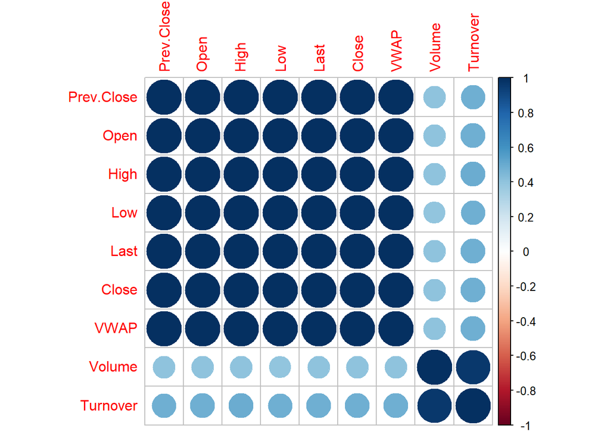

```r
stock1 %>%
  na.omit() %>%
  cor() %>%
  corrplot()
```

```r
stock1 %>%
  na.omit() %>%
  cor()
```

```
##            Prev.Close      Open      High       Low      Last     Close
## Prev.Close  1.0000000 0.9993020 0.9991645 0.9991701 0.9990991 0.9991167
## Open        0.9993020 1.0000000 0.9997644 0.9997652 0.9996391 0.9996551
## High        0.9991645 0.9997644 1.0000000 0.9996576 0.9998061 0.9998177
## Low         0.9991701 0.9997652 0.9996576 1.0000000 0.9998080 0.9998231
## Last        0.9990991 0.9996391 0.9998061 0.9998080 1.0000000 0.9999865
## Close       0.9991167 0.9996551 0.9998177 0.9998231 0.9999865 1.0000000
## VWAP        0.9992224 0.9997759 0.9998847 0.9998842 0.9999314 0.9999480
## Volume      0.4012583 0.4014437 0.4056046 0.3997646 0.4022780 0.4023323
## Turnover    0.4871787 0.4878454 0.4913178 0.4861510 0.4883579 0.4884282
##                 VWAP    Volume  Turnover
## Prev.Close 0.9992224 0.4012583 0.4871787
## Open       0.9997759 0.4014437 0.4878454
## High       0.9998847 0.4056046 0.4913178
## Low        0.9998842 0.3997646 0.4861510
## Last       0.9999314 0.4022780 0.4883579
## Close      0.9999480 0.4023323 0.4884282
## VWAP       1.0000000 0.4029828 0.4890053
## Volume     0.4029828 1.0000000 0.9643945
## Turnover   0.4890053 0.9643945 1.0000000
```

As it can be seen from the correlation plot - variables are highly correlated and therefore it cannot be used in models since multicollinearity problem. This is just an example of how PCA can be useful for such data.

There are clearly two groups of variables: the first is about prices and the second is about shares in stock market. So, 2 PC’s are expected.

## PCA

Proceeding to Principal Component Analysis. How much variance do the PCs retain?

```r
row.names(stock1) <- stock$Date
pca_scores <- prcomp(stock1)
cat("PC Eigenvalues\n")
```

```
## PC Eigenvalues
```

```r
pca_scores$sdev ^ 2
```

```
## [1] 7.50248392269 1.46439993678 0.03091899765 0.00132798386 0.00042260099
## [6] 0.00032155407 0.00008690510 0.00002667084 0.00001142802
```

As expected, by eigenvalues there are only two first highly informative PC’s, others are quite useless. Let’s visualize this.

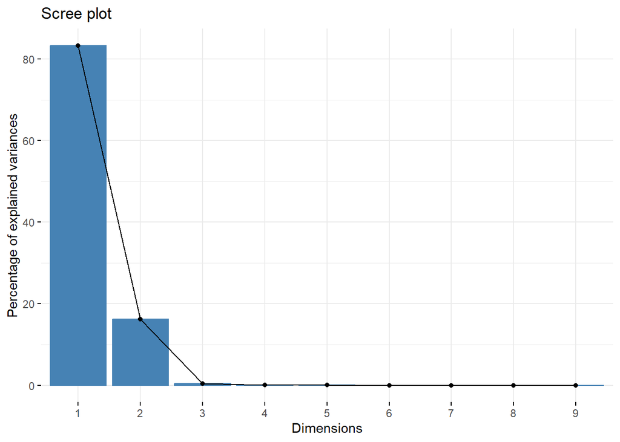

```r
fviz_screeplot(pca_scores, ncp=9)
```

By screeplot it can be seen that most of the variance is explained by the first principal component, second explains less and others - almost none.

```r
summary(pca_scores)
```

```
## Importance of components:
##                           PC1    PC2     PC3     PC4     PC5     PC6      PC7
## Standard deviation     2.7391 1.2101 0.17584 0.03644 0.02056 0.01793 0.009322
## Proportion of Variance 0.8336 0.1627 0.00344 0.00015 0.00005 0.00004 0.000010
## Cumulative Proportion  0.8336 0.9963 0.99976 0.99990 0.99995 0.99999 1.000000
##                             PC8      PC9
## Standard deviation     0.005164 0.003381
## Proportion of Variance 0.000000 0.000000
## Cumulative Proportion  1.000000 1.000000
```

By summary it can be seen that more than 99% of cumulative proportion of variance is explained by first two principal components.

## PC Interpretation

```r
pca_scores$rotation
```

```
##                  PC1        PC2          PC3          PC4          PC5
## Prev.Close 0.3616746  0.1093684 -0.015238569 -0.895395700  0.233771912
## Open       0.3618350  0.1091910 -0.004558621 -0.055133789 -0.776358753
## High       0.3620502  0.1056653 -0.016064770  0.133984285 -0.180485722
## Low        0.3617534  0.1107658 -0.006904138  0.137375128 -0.112965625
## Last       0.3618887  0.1085904 -0.011324920  0.257549723  0.395187504
## Close      0.3618959  0.1085388 -0.010915383  0.249756575  0.368667707
## VWAP       0.3619435  0.1079924 -0.011988971  0.172285893  0.071831976
## Volume     0.1890635 -0.6998040 -0.688802509  0.001433068 -0.003974496
## Turnover   0.2182679 -0.6540039  0.724293608 -0.002898616  0.004096402
##                     PC6          PC7            PC8           PC9
## Prev.Close -0.009031460  0.018600532  0.01357482999 -0.0018056430
## Open        0.030991322 -0.490337146 -0.09983565404 -0.0010843974
## High       -0.694679173  0.447169702  0.34681878728 -0.0643921412
## Low         0.717742680  0.429330702  0.34995206033 -0.0569101832
## Last       -0.029000244 -0.427459939  0.29943827056  0.6011531339
## Close      -0.018043356 -0.298342209 -0.10618780119 -0.7471464786
## VWAP        0.000325570  0.321234436 -0.80384051727  0.2701801355
## Volume      0.007181005 -0.003310748 -0.00009603228 -0.0003413334
## Turnover   -0.002452034  0.002304826  0.00037014717  0.0002718127
```

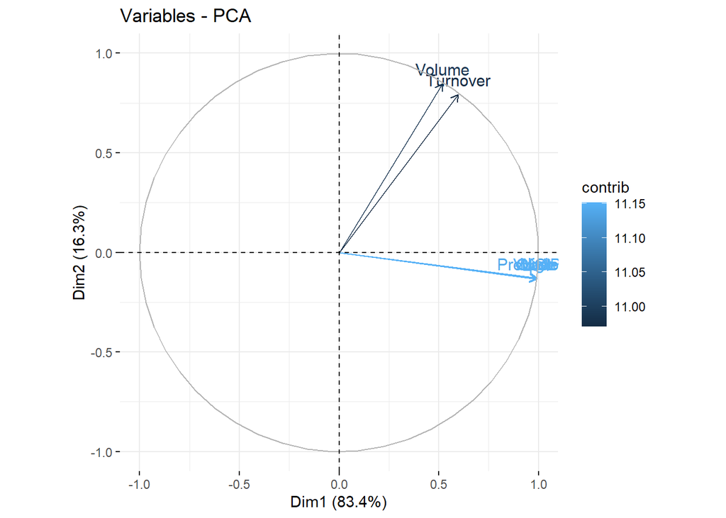

```r
stock_graphs <- PCA(stock1, graph = F)

fviz_pca_var(stock_graphs, col.var="contrib")
```

*PC1*: This principal component is mostly driven by Prev.Close, Open, High, Low, Last, and Close, which are all positively correlated with it. This component could represent overall market trend or general movement of stock prices.

*PC2*: This component is mostly driven by Volume and Turnover, which are both negatively correlated with it. This component could represent trading activity or liquidity.

Most of the variance is explained by the Stock Price changing as we can see by the “Variables - PCA” plot.

## Conclusions

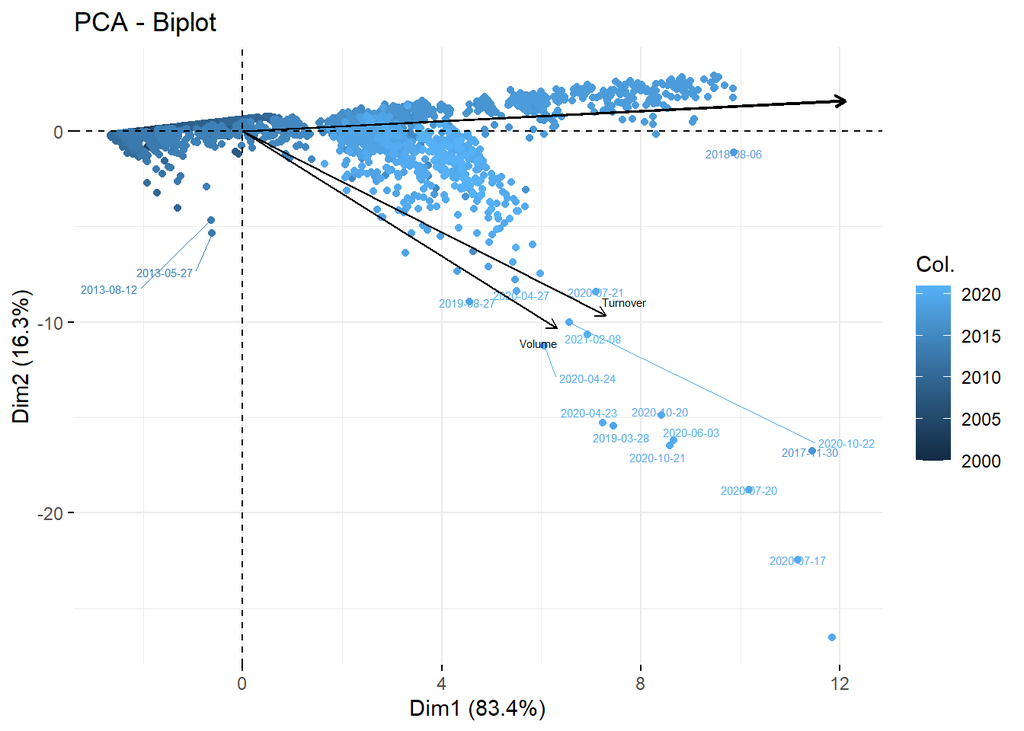

```r
fviz_pca_biplot(pca_scores, col.var = "black", col.ind=year(stock$Date), labelsize = 2, repel = T, )
```